# Mask Detection With Limited Data

In this project I showcased how to train a model with very limited data (in this case 100 images)

The way it works is we use a method called "transfer learning", in which we freeze pretrain layers that are trained on similar data or cases and then only train the deeper layers.

```python
!pip install ultralytics -q

from ultralytics import YOLO
import torch
import os

print("Torch version:", torch.__version__)
print("CUDA available:", torch.cuda.is_available())
```

```
   ━━━━━━━━━━━━━━━━━━━━━━━━━━━━━━━━━━━━━━━━ 1.1/1.1 MB 18.1 MB/s eta 0:00:00
Creating new Ultralytics Settings v0.0.6 file ✅
View Ultralytics Settings with 'yolo settings' or at '/root/.config/Ultralytics/settings.json'
Update Settings with 'yolo settings key=value', i.e. 'yolo settings runs_dir=path/to/dir'. For help see https://docs.ultralytics.com/quickstart/#ultralytics-settings.
Torch version: 2.8.0+cu126
CUDA available: True
```

```python
from google.colab import drive
drive.mount('/content/drive')

dataset_path = '/content/drive/MyDrive/maskDetection/data'
!ls $dataset_path
```

```
images	labels	test_images
```

```python
yaml_content = f"""
train: {dataset_path}/images/train
val: {dataset_path}/images/val

nc: 2
names: ['no_mask', 'mask']
"""

with open('mask_dataset.yaml', 'w') as f:
    f.write(yaml_content)

print("✅ Dataset YAML created successfully!")
!cat mask_dataset.yaml
```

```
✅ Dataset YAML created successfully!

train: /content/drive/MyDrive/maskDetection/data/images/train
val: /content/drive/MyDrive/maskDetection/data/images/val

nc: 2
names: ['no_mask', 'mask']
```

In this case we'll be using yolo v8 model, which was already trained on COCO dataset which works well with faces and should adapt well to training on mask detection.

```python
model = YOLO('yolov8s.pt')
```

```
Downloading https://github.com/ultralytics/assets/releases/download/v8.3.0/yolov8s.pt to 'yolov8s.pt': 100% ━━━━━━━━━━━━ 21.5MB 201.9MB/s 0.1s
```

In this case we will freeze the first 10 layers, which are responsible for a more abstract data extraction which we don't want to change, we want to change the more complex features (in this case masks).

```python
model.freeze = [0, 10]
```

Augmentation is another core principle to implementing this model, since we have very limited data we'll set augment=true so the model will think there are many images instead of the only 100 we provided. It works by flipping, zooming in and changing colors of the images we provided and by doing that, it creates more data to learn from.

```python
model.train(
    data='mask_dataset.yaml',
    epochs=50,
    imgsz=640,
    batch=8,
    freeze=10,
    name='mask_detector_small_data',
    augment=True,     # Enable strong augmentation
)
```

```
Ultralytics 8.3.227 🚀 Python-3.12.12 torch-2.8.0+cu126 CUDA:0 (Tesla T4, 15095MiB)
engine/trainer: agnostic_nms=False, amp=True, augment=True, auto_augment=randaugment, batch=8, bgr=0.0, box=7.5, cache=False, cfg=None, classes=None, close_mosaic=10, cls=0.5, compile=False, conf=None, copy_paste=0.0, copy_paste_mode=flip, cos_lr=False, cutmix=0.0, data=mask_dataset.yaml, degrees=0.…
Downloading https://ultralytics.com/assets/Arial.ttf to '/root/.config/Ultralytics/Arial.ttf': 100% ━━━━━━━━━━━━ 755.1KB 26.3MB/s 0.0s
Overriding model.yaml nc=80 with nc=2

                   from  n    params  module                                       arguments
  0                  -1  1       928  ultralytics.nn.modules.conv.Conv             [3, 32, 3, 2]
  1                  -1  1     18560  ultralytics.nn.modules.conv.Conv             [32, 64, 3, 2]
  2                  -1  1     29056  ultralytics.nn.modules.block.C2f             [64, 64, 1, True]
  3                  -1  1     73984  ultralytics.nn.modules.conv.Conv             [64, 128, 3, 2]
  4                  -1  2    197632  ultralytics.nn.modules.block.C2f             [128, 128, 2, True]
  5                  -1  1    295424  ultralytics.nn.modules.conv.Conv             [128, 256, 3, 2]
  6                  -1  2    788480  ultralytics.nn.modules.block.C2f             [256, 256, 2, True]
  7                  -1  1   1180672  ultralytics.nn.modules.conv.Conv             [256, 512, 3, 2]
  8                  -1  1   1838080  ultralytics.nn.modules.block.C2f             [512, 512, 1, True]
  9                  -1  1    656896  ultralytics.nn.modules.block.SPPF            [512, 512, 5]
 10                  -1  1         0  torch.nn.modules.upsampling.Upsample         [None, 2, 'nearest']
 11             [-1, 6]  1         0  ultralytics.nn.modules.conv.Concat           [1]
 12                  -1  1    591360  ultralytics.nn.modules.block.C2f             [768, 256, 1]
 13                  -1  1         0  torch.nn.modules.upsampling.Upsample         [None, 2, 'nearest']
 14             [-1, 4]  1         0  ultralytics.nn.modules.conv.Concat           [1]
 15                  -1  1    148224  ultralytics.nn.modules.block.C2f             [384, 128, 1]
 16                  -1  1    147712  ultralytics.nn.modules.conv.Conv             [128, 128, 3, 2]
 17            [-1, 12]  1         0  ultralytics.nn.modules.conv.Concat           [1]
 18                  -1  1    493056  ultralytics.nn.modules.block.C2f             [384, 256, 1]
 19                  -1  1    590336  ultralytics.nn.modules.conv.Conv             [256, 256, 3, 2]
 20             [-1, 9]  1         0  ultralytics.nn.modules.conv.Concat           [1]
 21                  -1  1   1969152  ultralytics.nn.modules.block.C2f             [768, 512, 1]
 22        [15, 18, 21]  1   2116822  ultralytics.nn.modules.head.Detect           [2, [128, 256, 512]]
Model summary: 129 layers, 11,136,374 parameters, 11,136,358 gradients, 28.6 GFLOPs

Transferred 349/355 items from pretrained weights
Freezing layer 'model.0.conv.weight'
Freezing layer 'model.0.bn.weight'
Freezing layer 'model.0.bn.bias'
Freezing layer 'model.1.conv.weight'
Freezing layer 'model.1.bn.weight'
Freezing layer 'model.1.bn.bias'
Freezing layer 'model.2.cv1.conv.weight'
Freezing layer 'model.2.cv1.bn.weight'
```

[output cut: 342 more lines]

```
                   all         20         43      0.828       0.61      0.657      0.264

50 epochs completed in 0.031 hours.
Optimizer stripped from /content/runs/detect/mask_detector_small_data/weights/last.pt, 22.5MB
Optimizer stripped from /content/runs/detect/mask_detector_small_data/weights/best.pt, 22.5MB

Validating /content/runs/detect/mask_detector_small_data/weights/best.pt...
Ultralytics 8.3.227 🚀 Python-3.12.12 torch-2.8.0+cu126 CUDA:0 (Tesla T4, 15095MiB)
Model summary (fused): 72 layers, 11,126,358 parameters, 0 gradients, 28.4 GFLOPs
                 Class     Images  Instances      Box(P          R      mAP50  mAP50-95): 100% ━━━━━━━━━━━━ 2/2 1.7it/s 1.2s
                   all         20         43      0.717      0.648      0.657      0.261
               no_mask          4         10      0.646        0.6      0.634      0.233
                  mask         18         33      0.789      0.697       0.68      0.289
Speed: 0.2ms preprocess, 54.1ms inference, 0.0ms loss, 0.8ms postprocess per image
Results saved to /content/runs/detect/mask_detector_small_data
```

[output not shown]

[output cut: 169 more lines]

```python
metrics = model.val()
print(metrics)
```

[output not shown]

[output cut: 170 more lines]

```python
test_images = '/content/drive/MyDrive/maskDetection/data/test_images'

# Run detection
results = model.predict(
    source=test_images,
    conf=0.5,
    save=True,
    imgsz=640
)
```

```
image 1/2 /content/drive/MyDrive/maskDetection/data/test_images/test1.jpg: 448x640 1 no_mask, 1 mask, 12.8ms
image 2/2 /content/drive/MyDrive/maskDetection/data/test_images/test2.jpg: 448x640 2 no_masks, 10 masks, 12.8ms
Speed: 5.7ms preprocess, 12.8ms inference, 2.0ms postprocess per image at shape (1, 3, 448, 640)
Results saved to /content/runs/detect/predict
```

```python
model.export(format='onnx')
```

```
Ultralytics 8.3.227 🚀 Python-3.12.12 torch-2.8.0+cu126 CPU (Intel Xeon CPU @ 2.20GHz)
💡 ProTip: Export to OpenVINO format for best performance on Intel hardware. Learn more at https://docs.ultralytics.com/integrations/openvino/

PyTorch: starting from '/content/runs/detect/mask_detector_small_data/weights/best.pt' with input shape (1, 3, 640, 640) BCHW and output shape(s) (1, 6, 8400) (21.5 MB)
requirements: Ultralytics requirements ['onnx>=1.12.0,<=1.19.1', 'onnxslim>=0.1.71', 'onnxruntime-gpu'] not found, attempting AutoUpdate...
Using Python 3.12.12 environment at: /usr
Resolved 14 packages in 185ms
Prepared 6 packages in 6.62s
Installed 6 packages in 247ms
 + colorama==0.4.6
 + coloredlogs==15.0.1
 + humanfriendly==10.0
 + onnx==1.19.1
 + onnxruntime-gpu==1.23.2
 + onnxslim==0.1.74

requirements: AutoUpdate success ✅ 7.7s
WARNING ⚠️ requirements: Restart runtime or rerun command for updates to take effect


ONNX: starting export with onnx 1.19.1 opset 22...
ONNX: slimming with onnxslim 0.1.74...
ONNX: export success ✅ 10.1s, saved as '/content/runs/detect/mask_detector_small_data/weights/best.onnx' (42.7 MB)

Export complete (11.0s)
Results saved to /content/runs/detect/mask_detector_small_data/weights
Predict:         yolo predict task=detect model=/content/runs/detect/mask_detector_small_data/weights/best.onnx imgsz=640
Validate:        yolo val task=detect model=/content/runs/detect/mask_detector_small_data/weights/best.onnx imgsz=640 data=mask_dataset.yaml
Visualize:       https://netron.app
```

```
'/content/runs/detect/mask_detector_small_data/weights/best.onnx'
```

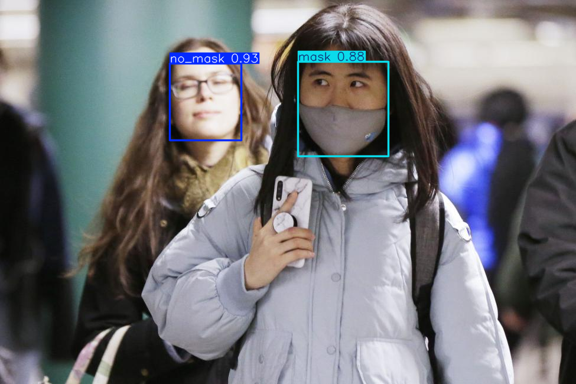

```python
results[0].show()
```